# Preliminary analysis of fire behavior data

DAM

2020-12-03

# Data

Everything is available in the [SpatialFireBehavior folder](https://github.com/devanmcg/FireScienceDIY/tree/master/SpatialFireBehavior) in the [FireScienceDIY GitHub project](https://github.com/devanmcg/FireScienceDIY).

## Preparations

The raw weather, fuels, and fire behavior data used here are available in an [Excel spreadsheet](https://github.com/devanmcg/FireScienceDIY/blob/master/SpatialFireBehavior/data/AllLocations.xlsx).  
These data were [loaded with this script](https://raw.githubusercontent.com/devanmcg/FireScienceDIY/master/SpatialFireBehavior/r%20script/LoadingData.R) and combined with [this script](https://raw.githubusercontent.com/devanmcg/FireScienceDIY/master/SpatialFireBehavior/r%20script/ConnectingData.R) into [$\texttt{DataCombined.R}$](https://github.com/devanmcg/FireScienceDIY/blob/master/SpatialFireBehavior/data/DataCombined.Rdata).

Data are limited to $\textsf{Rate of spread < 40 m/s}$ and $\textsf{Maximum temperature > 40}^\circ \textsf{C}$.

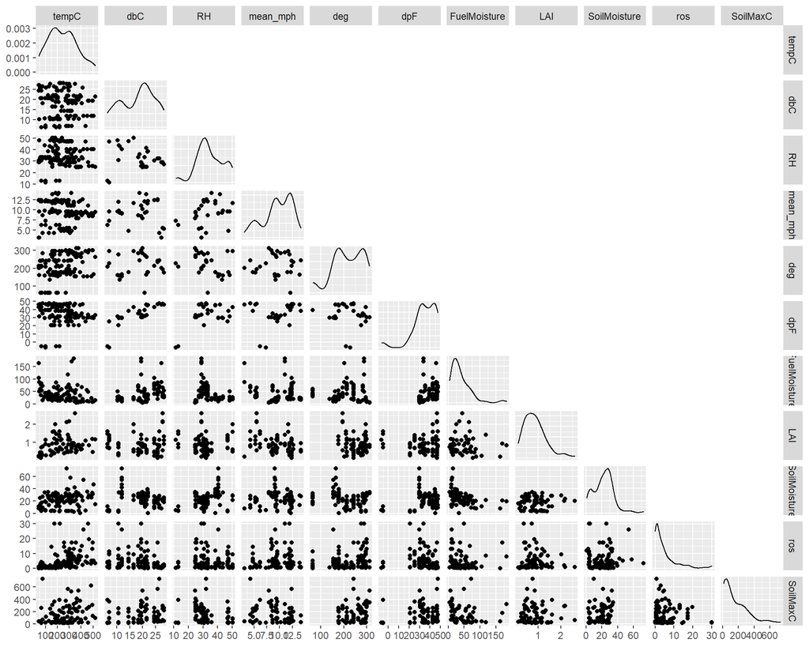

A scatterplot matrix of all raw data used in this analysis.

## Distributions

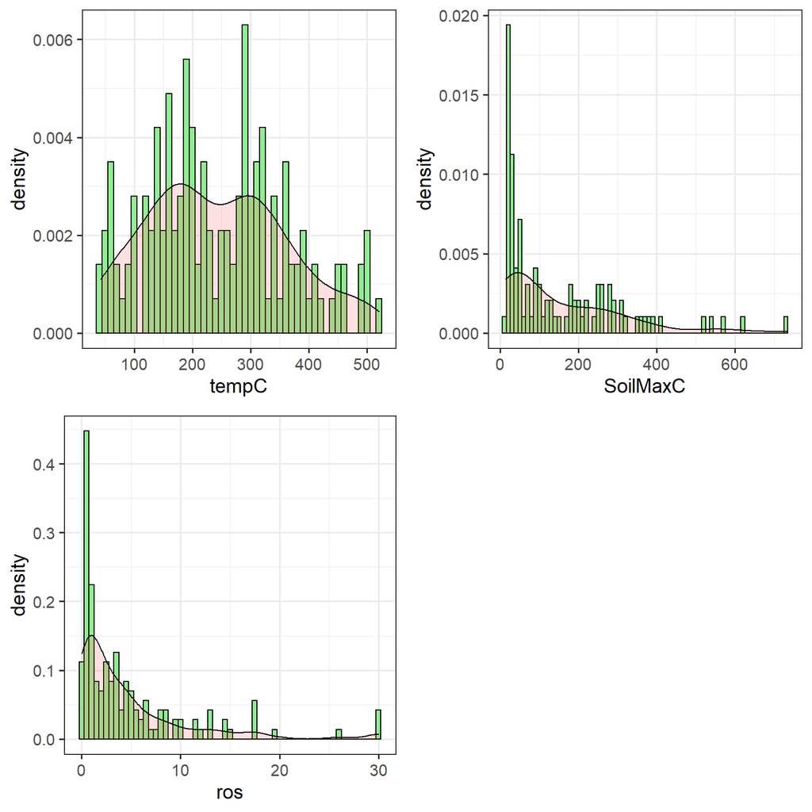

Gamma distributions are fit to all response variables.

## Correlations of interest

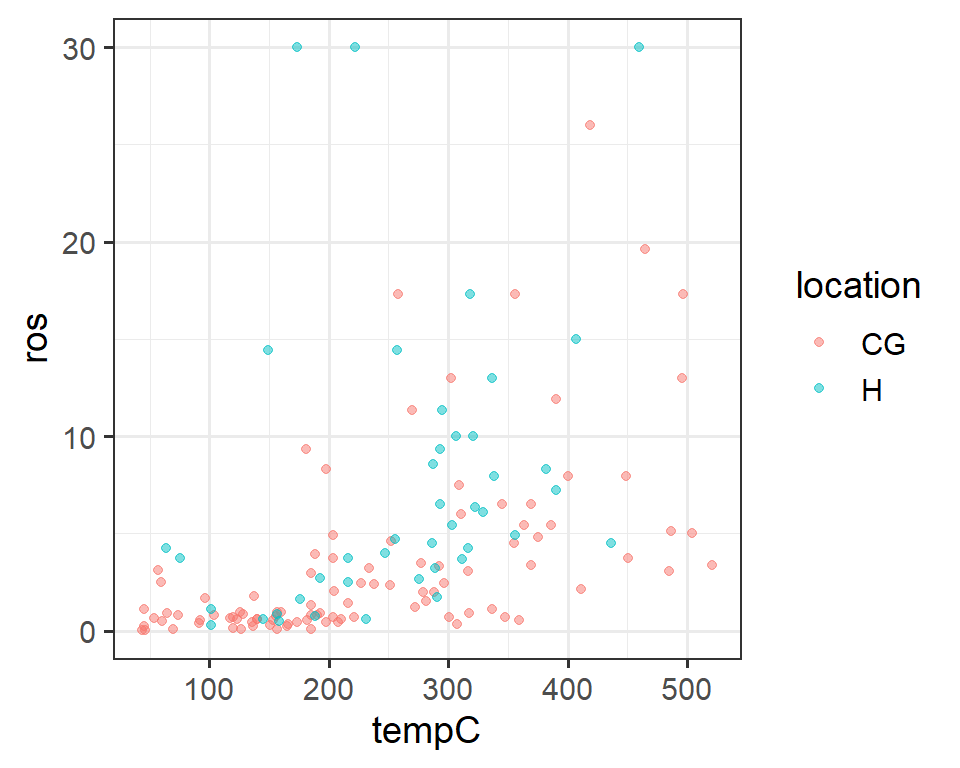

Poor linear relationship between rate of spread and maximum temperature.

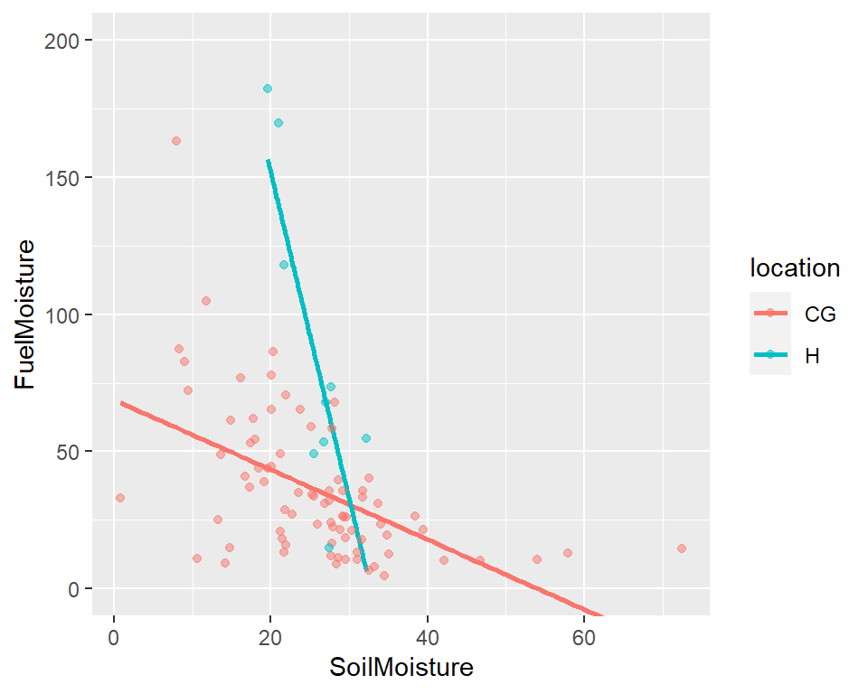

Unexpected and unexplained relationship between soil moisture and fuel moisture. Dropping soil moisture from predictor variables.

# Regression analysis

## Imputation of missing values

There are several missing values in the data:

Table of missing values by variable.

|  | tempC | ros | RH | mean_mph | deg | FuelMoisture | SoilMaxC | LAI |  |
| --- | --- | --- | --- | --- | --- | --- | --- | --- | --- |
| **56** | 1 | 1 | 1 | 1 | 1 | 1 | 1 | 1 | 0 |
| **1** | 1 | 1 | 1 | 1 | 1 | 1 | 1 | 0 | 1 |
| **37** | 1 | 1 | 1 | 1 | 1 | 1 | 0 | 0 | 2 |
| **21** | 1 | 1 | 1 | 1 | 1 | 0 | 1 | 1 | 1 |
| **6** | 1 | 1 | 1 | 1 | 1 | 0 | 1 | 0 | 2 |
| **3** | 1 | 1 | 0 | 0 | 0 | 1 | 1 | 0 | 4 |
| **8** | 1 | 1 | 0 | 0 | 0 | 1 | 0 | 0 | 5 |
| **11** | 1 | 1 | 0 | 0 | 0 | 0 | 1 | 0 | 5 |
|  | 0 | 0 | 22 | 22 | 22 | 38 | 45 | 66 | 215 |

Therefore I used the multiple imputation method in the **mice** package to fill in missing values. The method creates 100 datasets, each with different but reasonable values for the missing data based on patterns in existing data, and performs the regression analysis on each. These results are pooled into a single set of results.

## Model specification

Mixed-effect regression models fit with `lme4::glmer` and constructed as follows:

$$y \approx RH + WS + FM + FL + (1|location/block/year/plot),~
\text{family=Gamma(link = `log')}$$

where

$RH$ = Relative humidity,

$WS$ = Average wind speed,

$FM$ = Fuel moisture (from clipped samples),

$FL$ = Fuel load (as estimated by LAI)

Weather variables $RH$ and $WS$ were taken from NDAWN stations for the hour in which the fire behavior observation occurred.

All variables were scaled to a common range prior to analysis, and units for each predictor variable are not reported.

# Results

Fuel moisture reduced maximum temperature ($t_{67} = -2.74, P = 0.01$) whereas weather variables ($\textsf{Wind speed}$, $t_{68} = 2.69, P = 0.01$; $\textsf{RH}$, $t_{70} = -2.07, P = 0.04$ ) influenced rate of spread. These data might indicate that fuel variables are more important to first-order effects on basal plant tissue and soil heating.

Interestingly, there was a trend ($t_{66} = -1.94, P = 0.06$) towards higher temperature at the soil surface as RH declined. This likely indicates higher intensity fires that burn down through litter. The negative trend between wind speed and soil surface temperatures was not statistically significant ($t_{61} = -1.62, P = 0.11$).

Further work should include quantifying total heat exposure via infrared sensors.

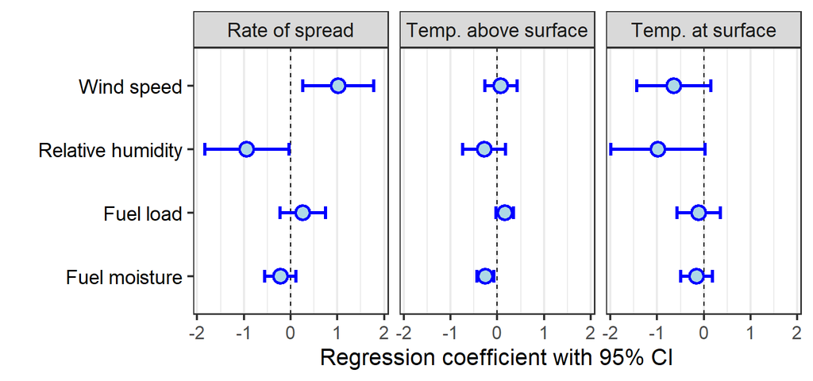

# Script

```r
# Packages
  pacman::p_load(tidyverse, mice, broom.mixed)
# Filter data
  AnalysisData <-
    DataCombined %>%
      filter( ros <= 40,
              tempC >= 40) %>%
        mutate(FuelMoisture = ifelse(FuelMoisture >= 0,
                                      FuelMoisture, NA),
               FuelMoisture = FuelMoisture * 100) %>%
  select(-lys)
# Scatterplot matrix
GGally::ggpairs(AnalysisData,
                columns = 8:18,
                upper = 'blank')
# Distributions of response variables
  ros_dist <-
  AnalysisData %>%
    ggplot(aes(x=ros)) + theme_bw(14) +
    geom_histogram(aes(y=..density..),
                   binwidth=0.5,
                   colour="black",
                   fill="lightgreen") +
    geom_density(alpha=0.2,
                 fill="#FF6666")
  tempC_dist <-
  AnalysisData %>%
    ggplot(aes(x=tempC)) + theme_bw(14) +
    geom_histogram(aes(y=..density..),
                   binwidth=10,
                   colour="black",
                   fill="lightgreen") +
    geom_density(alpha=0.2,
                 fill="#FF6666")
  soilC_dist <-
  AnalysisData %>%
  ggplot(aes(x=SoilMaxC)) + theme_bw(14) +
  geom_histogram(aes(y=..density..),
                 binwidth=10,
                 colour="black",
                 fill="lightgreen") +
  geom_density(alpha=0.2,
               fill="#FF6666")
  gridExtra::grid.arrange(tempC_dist, soilC_dist,
                          ros_dist, ncol=2)
# ROS fit against maximum temperature
  AnalysisData %>%
    ggplot(aes(x=tempC, y = ros, color=location)) + theme_bw(14) +
      geom_point(alpha=0.5)
# Fuel moisture fit against soil moisture
  ggplot(AnalysisData, aes(x=SoilMoisture, y=FuelMoisture, color=location)) +
    geom_smooth(method = 'lm', se=F) +
    geom_point(alpha=0.5) +
    coord_cartesian(ylim = c(0,200))
# MICE operations
#
# Pattern of missing data
AnalysisData %>%
  select(-location, -block, -pasture,-patch,
         -year, -plot, -array, -dbC, -dpF, -SoilMoisture) %>%
    md.pattern(plot = F) %>%
  pander::pander(caption="Table of missing values by variable.")
# Calculate imputed datasets
  imp <- AnalysisData %>%
              mutate_at(vars(plot, array), as.character) %>%
              mutate_at(vars(tempC:ros), ~as.numeric(scale(., center=F))) %>%
              select(-SoilMoisture, -dpF) %>%
               mice(m=100, seed = 23109, print=F)
# Rate of spread
  # Fit model
    ros_all <- with(imp,
                  suppressMessages(
                    lme4::glmer(ros ~ RH + mean_mph +
                               FuelMoisture + LAI +
                            (1|location/block/year/plot),
                       family=Gamma(link = "log"),
                       control=lme4::glmerControl(optimizer="bobyqa",
                                        optCtrl=list(maxfun=100000)) )) )
    # Pool results
    ros_terms <-
      summary(pool(ros_all)) %>%
        mutate_at(vars(estimate:p.value), ~round(., 2)) %>%
        select(term, estimate) %>%
      bind_cols(confint.mipo(pool(ros_all)) %>%
                  as_tibble() %>%
                  round(2) ) %>%
        arrange(desc(abs(estimate)))
# Maximum temperature
   # Fit model
    temp_all <- with(imp,
                  suppressMessages(
                    lme4::glmer(tempC ~ RH + mean_mph +
                             FuelMoisture + LAI +
                             (1|location/block/year/plot),
                        family=Gamma(link = "log"),
                        control=lme4::glmerControl(optimizer="bobyqa",
                                      optCtrl=list(maxfun=100000)) )) )

  # Pool results
    temp_terms <-
     summary(pool(temp_all)) %>%
     mutate_at(vars(estimate:p.value), ~round(., 2)) %>%
     select(term, estimate) %>%
     bind_cols(confint.mipo(pool(temp_all)) %>%
                 as_tibble() %>%
                 round(2) ) %>%
     arrange(desc(abs(estimate)))

#
# Maximum soil surface temperature
#
  # Fit model
   soil_all <- with(imp, suppressMessages(
     lme4::glmer(SoilMaxC ~ RH + mean_mph +
                   FuelMoisture + LAI +
                   (1|location/block/year/plot),
                 family=Gamma(link = "log"),
                 control=lme4::glmerControl(optimizer="bobyqa",
                                  optCtrl=list(maxfun=100000)) )) )
  # Pool results
   soil_terms <-
     summary(pool(soil_all)) %>%
     mutate_at(vars(estimate:p.value), ~round(., 2)) %>%
     select(term, estimate) %>%
     bind_cols(confint.mipo(pool(soil_all)) %>%
                 as_tibble() %>%
                 round(2) ) %>%
     arrange(desc(abs(estimate)))

# Combine regression results
  response_CIs <-
          bind_rows(
            mutate(soil_terms, response = 'Temp. at surface'),
            mutate(temp_terms, response = 'Temp. above surface'),
            mutate(ros_terms, response = "Rate of spread")
            )
# Plot confidence intervals
response_CIs %>%
  filter(term != '(Intercept)') %>%
  as_tibble() %>%
  mutate(term = recode(term, LAI = 'Fuel load',
                             mean_mph = 'Wind speed',
                             RH = 'Relative humidity',
                             FuelMoisture = 'Fuel moisture'))  %>%
  ggplot(aes(x = reorder(term, abs(estimate), max))) + theme_bw(16) +
    geom_hline(yintercept = 0, color="black", linetype = 2) +
    geom_errorbar(aes(ymin = `2.5 %`, ymax = `97.5 %`),
                  size = 1.1, width = 0.2,
                  color = "blue") +
    geom_point(aes(y = estimate), pch = 21,
               stroke = 1.5, size = 4,
               color = "blue", fill="lightblue") +
    labs(x = '',
         y = 'Regression coefficient with 95% CI') +
    coord_flip(ylim=c(-1.9,1.9)) +
    facet_wrap(~ response) +
    theme(axis.text.y = element_text(color="black", size = 14),
          strip.text = element_text(size = 14),
          panel.grid.major.y = element_blank())
```